# Risk Factor Analysis

## Outcome Variable

**Outcome Variable:** stunted

## Predictor Variables

**Intervention Variable:** fage

**Adjustment Set:**

unadjusted

## Stratifying Variables

The analysis was stratified on these variable(s):

- agecat
- studyid

The following strata were considered:

- agecat: 12 months, studyid: ki0047075b-MAL-ED
- agecat: 12 months, studyid: ki1000304b-SAS-FoodSuppl
- agecat: 12 months, studyid: ki1135781-COHORTS
- agecat: 12 months, studyid: ki1148112-LCNI-5
- agecat: 18 months, studyid: ki0047075b-MAL-ED
- agecat: 18 months, studyid: ki1000304b-SAS-FoodSuppl
- agecat: 18 months, studyid: ki1135781-COHORTS
- agecat: 18 months, studyid: ki1148112-LCNI-5
- agecat: 24 months, studyid: ki0047075b-MAL-ED
- agecat: 24 months, studyid: ki1135781-COHORTS
- agecat: 24 months, studyid: ki1148112-LCNI-5
- agecat: 3 months, studyid: ki0047075b-MAL-ED
- agecat: 3 months, studyid: ki1000304b-SAS-FoodSuppl
- agecat: 3 months, studyid: ki1135781-COHORTS
- agecat: 6 months, studyid: ki0047075b-MAL-ED
- agecat: 6 months, studyid: ki1000304b-SAS-FoodSuppl
- agecat: 6 months, studyid: ki1135781-COHORTS
- agecat: 6 months, studyid: ki1148112-LCNI-5
- agecat: 9 months, studyid: ki0047075b-MAL-ED
- agecat: 9 months, studyid: ki1000304b-SAS-FoodSuppl
- agecat: 9 months, studyid: ki1135781-COHORTS
- agecat: 9 months, studyid: ki1148112-LCNI-5
- agecat: Birth, studyid: ki0047075b-MAL-ED
- agecat: Birth, studyid: ki1135781-COHORTS

### Dropped Strata

Some strata were dropped due to rare outcomes:

- agecat: Birth, studyid: ki0047075b-MAL-ED
- agecat: 3 months, studyid: ki0047075b-MAL-ED
- agecat: 6 months, studyid: ki1148112-LCNI-5
- agecat: 9 months, studyid: ki0047075b-MAL-ED
- agecat: 9 months, studyid: ki1000304b-SAS-FoodSuppl
- agecat: 9 months, studyid: ki1148112-LCNI-5
- agecat: 12 months, studyid: ki1000304b-SAS-FoodSuppl
- agecat: 12 months, studyid: ki1148112-LCNI-5
- agecat: 18 months, studyid: ki1000304b-SAS-FoodSuppl
- agecat: 18 months, studyid: ki1148112-LCNI-5
- agecat: 24 months, studyid: ki1148112-LCNI-5

## Methods Detail

We’re interested in the causal parameters $E[Y_a]$ for all values of $a \in \mathcal{A}$. These parameters represent the mean outcome if, possibly contrary to fact, we intervened to set all units to have $A=a$. Under the randomization and positivity assumptions, these are identified by the statistical parameters $\psi_a=E_W[E_{Y|A,W}(Y|A=a,W)]$. In addition, we’re interested in the mean of $Y$, $E[Y]$ under no intervention (the observed mean). We will estimate these parameters by using SuperLearner to fit the relevant likelihood factors – $E_{Y|A,W}(Y|A=a,W)$ and $p(A=a|W)$, and then updating our likelihood fit using a joint TMLE.

For unadjusted analyses ($W=\{\}$), initial likelihoods were estimated using Lrnr_glm to estimate the simple $E(Y|A)$ and Lrnr_mean to estimate $p(A)$. For adjusted analyses, a small library containing Lrnr_glmnet, Lrnr_xgboost, and Lrnr_mean was used.

Having estimated these parameters, we will then use the delta method to estimate relative risks and attributable risks relative to a prespecified baseline level of $A$.

# Results Detail

## Results Plots

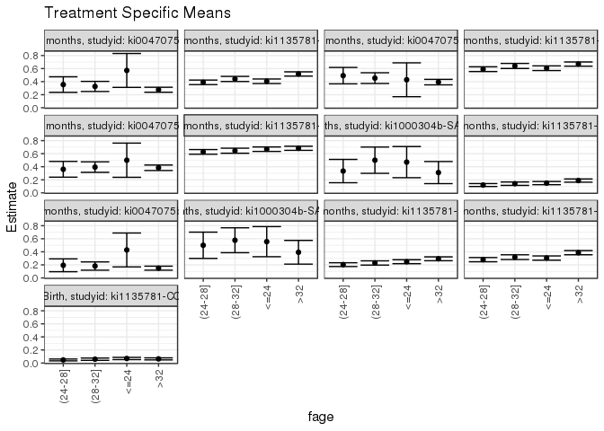

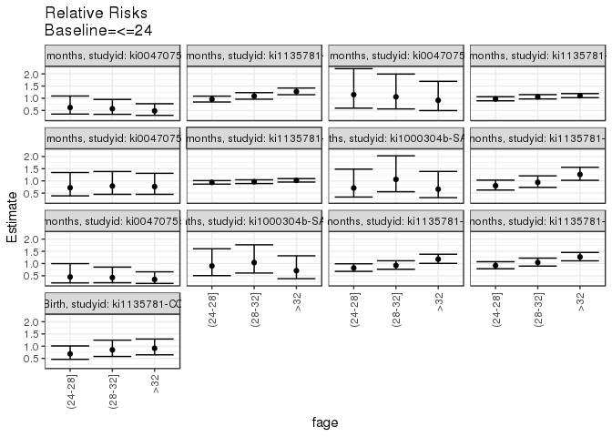

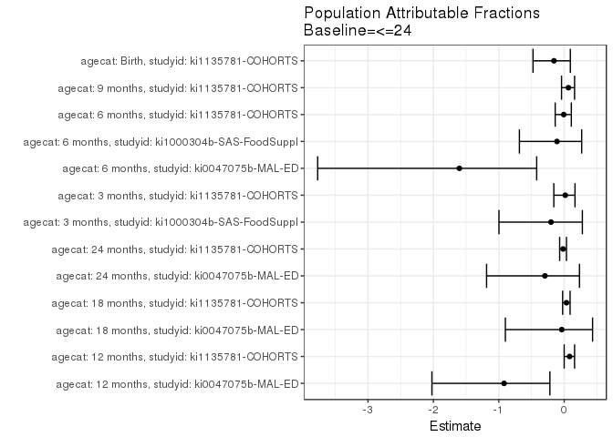

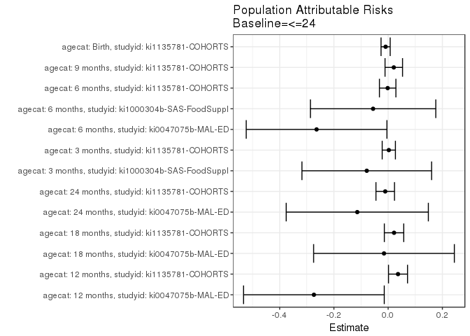

## Data Summary

| agecat | studyid | A | n | nA | nAY0 | nAY1 |
| --- | --- | --- | --- | --- | --- | --- |
| Birth | ki0047075b-MAL-ED | <=24 | 607 | 11 | 10 | 1 |
| Birth | ki0047075b-MAL-ED | (24-28] | 607 | 54 | 47 | 7 |
| Birth | ki0047075b-MAL-ED | (28-32] | 607 | 111 | 94 | 17 |
| Birth | ki0047075b-MAL-ED | >32 | 607 | 431 | 380 | 51 |
| Birth | ki1000304b-SAS-FoodSuppl | <=24 | 0 | 0 | 0 | 0 |
| Birth | ki1000304b-SAS-FoodSuppl | (24-28] | 0 | 0 | 0 | 0 |
| Birth | ki1000304b-SAS-FoodSuppl | (28-32] | 0 | 0 | 0 | 0 |
| Birth | ki1000304b-SAS-FoodSuppl | >32 | 0 | 0 | 0 | 0 |
| Birth | ki1135781-COHORTS | <=24 | 3334 | 869 | 809 | 60 |
| Birth | ki1135781-COHORTS | (24-28] | 3334 | 829 | 790 | 39 |
| Birth | ki1135781-COHORTS | (28-32] | 3334 | 700 | 659 | 41 |
| Birth | ki1135781-COHORTS | >32 | 3334 | 936 | 877 | 59 |
| Birth | ki1148112-LCNI-5 | <=24 | 0 | 0 | 0 | 0 |
| Birth | ki1148112-LCNI-5 | (24-28] | 0 | 0 | 0 | 0 |
| Birth | ki1148112-LCNI-5 | (28-32] | 0 | 0 | 0 | 0 |
| Birth | ki1148112-LCNI-5 | >32 | 0 | 0 | 0 | 0 |
| 3 months | ki0047075b-MAL-ED | <=24 | 744 | 14 | 11 | 3 |
| 3 months | ki0047075b-MAL-ED | (24-28] | 744 | 63 | 49 | 14 |
| 3 months | ki0047075b-MAL-ED | (28-32] | 744 | 143 | 120 | 23 |
| 3 months | ki0047075b-MAL-ED | >32 | 744 | 524 | 461 | 63 |
| 3 months | ki1000304b-SAS-FoodSuppl | <=24 | 97 | 17 | 9 | 8 |
| 3 months | ki1000304b-SAS-FoodSuppl | (24-28] | 97 | 27 | 18 | 9 |
| 3 months | ki1000304b-SAS-FoodSuppl | (28-32] | 97 | 24 | 12 | 12 |
| 3 months | ki1000304b-SAS-FoodSuppl | >32 | 97 | 29 | 20 | 9 |
| 3 months | ki1135781-COHORTS | <=24 | 3240 | 820 | 698 | 122 |
| 3 months | ki1135781-COHORTS | (24-28] | 3240 | 795 | 700 | 95 |
| 3 months | ki1135781-COHORTS | (28-32] | 3240 | 678 | 583 | 95 |
| 3 months | ki1135781-COHORTS | >32 | 3240 | 947 | 769 | 178 |
| 3 months | ki1148112-LCNI-5 | <=24 | 0 | 0 | 0 | 0 |
| 3 months | ki1148112-LCNI-5 | (24-28] | 0 | 0 | 0 | 0 |

[output cut: 82 more lines]

## Results Table

### Parameter: TSM

| agecat | studyid | intervention_level | baseline_level | estimate | ci_lower | ci_upper |
| --- | --- | --- | --- | --- | --- | --- |
| Birth | ki1135781-COHORTS | <=24 | NA | 0.0690449 | 0.0521858 | 0.0859039 |
| Birth | ki1135781-COHORTS | (24-28] | NA | 0.0470446 | 0.0326292 | 0.0614601 |
| Birth | ki1135781-COHORTS | (28-32] | NA | 0.0585714 | 0.0411734 | 0.0759695 |
| Birth | ki1135781-COHORTS | >32 | NA | 0.0630342 | 0.0474629 | 0.0786055 |
| 3 months | ki1000304b-SAS-FoodSuppl | <=24 | NA | 0.4705882 | 0.2320867 | 0.7090898 |
| 3 months | ki1000304b-SAS-FoodSuppl | (24-28] | NA | 0.3333333 | 0.1545981 | 0.5120686 |
| 3 months | ki1000304b-SAS-FoodSuppl | (28-32] | NA | 0.5000000 | 0.2989228 | 0.7010772 |
| 3 months | ki1000304b-SAS-FoodSuppl | >32 | NA | 0.3103448 | 0.1410914 | 0.4795983 |
| 3 months | ki1135781-COHORTS | <=24 | NA | 0.1487805 | 0.1244191 | 0.1731419 |
| 3 months | ki1135781-COHORTS | (24-28] | NA | 0.1194969 | 0.0969454 | 0.1420483 |
| 3 months | ki1135781-COHORTS | (28-32] | NA | 0.1401180 | 0.1139864 | 0.1662496 |
| 3 months | ki1135781-COHORTS | >32 | NA | 0.1879620 | 0.1630755 | 0.2128485 |
| 6 months | ki0047075b-MAL-ED | <=24 | NA | 0.4285714 | 0.1691715 | 0.6879714 |
| 6 months | ki0047075b-MAL-ED | (24-28] | NA | 0.1935484 | 0.0951406 | 0.2919562 |
| 6 months | ki0047075b-MAL-ED | (28-32] | NA | 0.1818182 | 0.1185600 | 0.2450764 |
| 6 months | ki0047075b-MAL-ED | >32 | NA | 0.1494253 | 0.1188216 | 0.1800290 |
| 6 months | ki1000304b-SAS-FoodSuppl | <=24 | NA | 0.5555556 | 0.3247968 | 0.7863143 |
| 6 months | ki1000304b-SAS-FoodSuppl | (24-28] | NA | 0.5000000 | 0.2989119 | 0.7010881 |
| 6 months | ki1000304b-SAS-FoodSuppl | (28-32] | NA | 0.5769231 | 0.3860240 | 0.7678222 |
| 6 months | ki1000304b-SAS-FoodSuppl | >32 | NA | 0.3928571 | 0.2110103 | 0.5747039 |
| 6 months | ki1135781-COHORTS | <=24 | NA | 0.2483995 | 0.2180911 | 0.2787078 |
| 6 months | ki1135781-COHORTS | (24-28] | NA | 0.2035040 | 0.1745309 | 0.2324772 |
| 6 months | ki1135781-COHORTS | (28-32] | NA | 0.2293292 | 0.1967790 | 0.2618794 |
| 6 months | ki1135781-COHORTS | >32 | NA | 0.2928177 | 0.2631653 | 0.3224700 |
| 9 months | ki1135781-COHORTS | <=24 | NA | 0.3043478 | 0.2720928 | 0.3366028 |
| 9 months | ki1135781-COHORTS | (24-28] | NA | 0.2796272 | 0.2475226 | 0.3117318 |
| 9 months | ki1135781-COHORTS | (28-32] | NA | 0.3181818 | 0.2820341 | 0.3543295 |
| 9 months | ki1135781-COHORTS | >32 | NA | 0.3867713 | 0.3548063 | 0.4187363 |
| 12 months | ki0047075b-MAL-ED | <=24 | NA | 0.5714286 | 0.3120281 | 0.8308290 |
| 12 months | ki0047075b-MAL-ED | (24-28] | NA | 0.3548387 | 0.2356608 | 0.4740167 |
| 12 months | ki0047075b-MAL-ED | (28-32] | NA | 0.3262411 | 0.2488031 | 0.4036791 |
| 12 months | ki0047075b-MAL-ED | >32 | NA | 0.2758621 | 0.2374946 | 0.3142296 |
| 12 months | ki1135781-COHORTS | <=24 | NA | 0.4055482 | 0.3705656 | 0.4405308 |
| 12 months | ki1135781-COHORTS | (24-28] | NA | 0.3891892 | 0.3540543 | 0.4243240 |
| 12 months | ki1135781-COHORTS | (28-32] | NA | 0.4408946 | 0.4019948 | 0.4797944 |
| 12 months | ki1135781-COHORTS | >32 | NA | 0.5173572 | 0.4845777 | 0.5501367 |
| 18 months | ki0047075b-MAL-ED | <=24 | NA | 0.4285714 | 0.1691708 | 0.6879721 |
| 18 months | ki0047075b-MAL-ED | (24-28] | NA | 0.4918033 | 0.3662612 | 0.6173453 |
| 18 months | ki0047075b-MAL-ED | (28-32] | NA | 0.4539007 | 0.3716671 | 0.5361343 |
| 18 months | ki0047075b-MAL-ED | >32 | NA | 0.3927203 | 0.3507982 | 0.4346424 |
| 18 months | ki1135781-COHORTS | <=24 | NA | 0.6058496 | 0.5700996 | 0.6415996 |
| 18 months | ki1135781-COHORTS | (24-28] | NA | 0.5909091 | 0.5545838 | 0.6272343 |
| 18 months | ki1135781-COHORTS | (28-32] | NA | 0.6402027 | 0.6015347 | 0.6788707 |
| 18 months | ki1135781-COHORTS | >32 | NA | 0.6691087 | 0.6368777 | 0.7013397 |
| 24 months | ki0047075b-MAL-ED | <=24 | NA | 0.5000000 | 0.2379112 | 0.7620888 |
| 24 months | ki0047075b-MAL-ED | (24-28] | NA | 0.3606557 | 0.2400713 | 0.4812402 |
| 24 months | ki0047075b-MAL-ED | (28-32] | NA | 0.3943662 | 0.3139297 | 0.4748027 |
| 24 months | ki0047075b-MAL-ED | >32 | NA | 0.3838772 | 0.3420890 | 0.4256653 |
| 24 months | ki1135781-COHORTS | <=24 | NA | 0.6684932 | 0.6343379 | 0.7026484 |
| 24 months | ki1135781-COHORTS | (24-28] | NA | 0.6271429 | 0.5913143 | 0.6629714 |
| 24 months | ki1135781-COHORTS | (28-32] | NA | 0.6450512 | 0.6063027 | 0.6837997 |
| 24 months | ki1135781-COHORTS | >32 | NA | 0.6823529 | 0.6510496 | 0.7136563 |

### Parameter: E(Y)

| agecat | studyid | intervention_level | baseline_level | estimate | ci_lower | ci_upper |
| --- | --- | --- | --- | --- | --- | --- |
| Birth | ki1135781-COHORTS | NA | NA | 0.0596881 | 0.0594123 | 0.0599638 |
| 3 months | ki1000304b-SAS-FoodSuppl | NA | NA | 0.3917526 | 0.3751125 | 0.4083927 |
| 3 months | ki1135781-COHORTS | NA | NA | 0.1512346 | 0.1503439 | 0.1521252 |
| 6 months | ki0047075b-MAL-ED | NA | NA | 0.1646424 | 0.1617549 | 0.1675298 |
| 6 months | ki1000304b-SAS-FoodSuppl | NA | NA | 0.5000000 | 0.4850470 | 0.5149530 |
| 6 months | ki1135781-COHORTS | NA | NA | 0.2466601 | 0.2454643 | 0.2478560 |
| 9 months | ki1135781-COHORTS | NA | NA | 0.3251714 | 0.3236963 | 0.3266465 |
| 12 months | ki0047075b-MAL-ED | NA | NA | 0.2976996 | 0.2943266 | 0.3010726 |
| 12 months | ki1135781-COHORTS | NA | NA | 0.4419761 | 0.4401216 | 0.4438307 |
| 18 months | ki0047075b-MAL-ED | NA | NA | 0.4132791 | 0.4108540 | 0.4157042 |
| 18 months | ki1135781-COHORTS | NA | NA | 0.6276032 | 0.6264469 | 0.6287596 |
| 24 months | ki0047075b-MAL-ED | NA | NA | 0.3861789 | 0.3848950 | 0.3874627 |
| 24 months | ki1135781-COHORTS | NA | NA | 0.6577111 | 0.6569167 | 0.6585055 |

### Parameter: RR

| agecat | studyid | intervention_level | baseline_level | estimate | ci_lower | ci_upper |
| --- | --- | --- | --- | --- | --- | --- |
| Birth | ki1135781-COHORTS | (24-28] | <=24 | 0.6813631 | 0.4604874 | 1.0081831 |
| Birth | ki1135781-COHORTS | (28-32] | <=24 | 0.8483095 | 0.5775108 | 1.2460876 |
| Birth | ki1135781-COHORTS | >32 | <=24 | 0.9129452 | 0.6450549 | 1.2920897 |
| 3 months | ki1000304b-SAS-FoodSuppl | (24-28] | <=24 | 0.7083333 | 0.3386931 | 1.4813885 |
| 3 months | ki1000304b-SAS-FoodSuppl | (28-32] | <=24 | 1.0625000 | 0.5563482 | 2.0291362 |
| 3 months | ki1000304b-SAS-FoodSuppl | >32 | <=24 | 0.6594828 | 0.3132329 | 1.3884795 |
| 3 months | ki1135781-COHORTS | (24-28] | <=24 | 0.8031756 | 0.6256060 | 1.0311458 |
| 3 months | ki1135781-COHORTS | (28-32] | <=24 | 0.9417767 | 0.7347942 | 1.2070637 |
| 3 months | ki1135781-COHORTS | >32 | <=24 | 1.2633510 | 1.0234655 | 1.5594623 |
| 6 months | ki0047075b-MAL-ED | (24-28] | <=24 | 0.4516129 | 0.2048638 | 0.9955603 |
| 6 months | ki0047075b-MAL-ED | (28-32] | <=24 | 0.4242424 | 0.2110653 | 0.8527297 |
| 6 months | ki0047075b-MAL-ED | >32 | <=24 | 0.3486590 | 0.1840330 | 0.6605506 |
| 6 months | ki1000304b-SAS-FoodSuppl | (24-28] | <=24 | 0.9000000 | 0.5048342 | 1.6044870 |
| 6 months | ki1000304b-SAS-FoodSuppl | (28-32] | <=24 | 1.0384615 | 0.6105999 | 1.7661359 |
| 6 months | ki1000304b-SAS-FoodSuppl | >32 | <=24 | 0.7071429 | 0.3796725 | 1.3170589 |
| 6 months | ki1135781-COHORTS | (24-28] | <=24 | 0.8192611 | 0.6791898 | 0.9882198 |
| 6 months | ki1135781-COHORTS | (28-32] | <=24 | 0.9232272 | 0.7656329 | 1.1132600 |
| 6 months | ki1135781-COHORTS | >32 | <=24 | 1.1788176 | 1.0059665 | 1.3813689 |
| 9 months | ki1135781-COHORTS | (24-28] | <=24 | 0.9187750 | 0.7858707 | 1.0741556 |
| 9 months | ki1135781-COHORTS | (28-32] | <=24 | 1.0454545 | 0.8950159 | 1.2211797 |
| 9 months | ki1135781-COHORTS | >32 | <=24 | 1.2708200 | 1.1110067 | 1.4536216 |
| 12 months | ki0047075b-MAL-ED | (24-28] | <=24 | 0.6209677 | 0.3530422 | 1.0922235 |
| 12 months | ki0047075b-MAL-ED | (28-32] | <=24 | 0.5709220 | 0.3420613 | 0.9529051 |
| 12 months | ki0047075b-MAL-ED | >32 | <=24 | 0.4827586 | 0.3002867 | 0.7761112 |
| 12 months | ki1135781-COHORTS | (24-28] | <=24 | 0.9596619 | 0.8470149 | 1.0872903 |
| 12 months | ki1135781-COHORTS | (28-32] | <=24 | 1.0871570 | 0.9609582 | 1.2299289 |
| 12 months | ki1135781-COHORTS | >32 | <=24 | 1.2756984 | 1.1462145 | 1.4198097 |
| 18 months | ki0047075b-MAL-ED | (24-28] | <=24 | 1.1475410 | 0.5949522 | 2.2133716 |
| 18 months | ki0047075b-MAL-ED | (28-32] | <=24 | 1.0591017 | 0.5630539 | 1.9921651 |
| 18 months | ki0047075b-MAL-ED | >32 | <=24 | 0.9163474 | 0.4956084 | 1.6942662 |
| 18 months | ki1135781-COHORTS | (24-28] | <=24 | 0.9753396 | 0.8956723 | 1.0620931 |
| 18 months | ki1135781-COHORTS | (28-32] | <=24 | 1.0567024 | 0.9711381 | 1.1498055 |
| 18 months | ki1135781-COHORTS | >32 | <=24 | 1.1044138 | 1.0234117 | 1.1918272 |
| 24 months | ki0047075b-MAL-ED | (24-28] | <=24 | 0.7213115 | 0.3873540 | 1.3431906 |
| 24 months | ki0047075b-MAL-ED | (28-32] | <=24 | 0.7887324 | 0.4494232 | 1.3842159 |
| 24 months | ki0047075b-MAL-ED | >32 | <=24 | 0.7677543 | 0.4494874 | 1.3113752 |
| 24 months | ki1135781-COHORTS | (24-28] | <=24 | 0.9381440 | 0.8689274 | 1.0128743 |
| 24 months | ki1135781-COHORTS | (28-32] | <=24 | 0.9649331 | 0.8917614 | 1.0441089 |
| 24 months | ki1135781-COHORTS | >32 | <=24 | 1.0207329 | 0.9529952 | 1.0932852 |

### Parameter: PAR

| agecat | studyid | intervention_level | baseline_level | estimate | ci_lower | ci_upper |
| --- | --- | --- | --- | --- | --- | --- |
| Birth | ki1135781-COHORTS | <=24 | NA | -0.0093568 | -0.0262181 | 0.0075045 |
| 3 months | ki1000304b-SAS-FoodSuppl | <=24 | NA | -0.0788357 | -0.3179170 | 0.1602457 |
| 3 months | ki1135781-COHORTS | <=24 | NA | 0.0024541 | -0.0219236 | 0.0268317 |
| 6 months | ki0047075b-MAL-ED | <=24 | NA | -0.2639291 | -0.5233451 | -0.0045130 |
| 6 months | ki1000304b-SAS-FoodSuppl | <=24 | NA | -0.0555556 | -0.2867983 | 0.1756871 |
| 6 months | ki1135781-COHORTS | <=24 | NA | -0.0017393 | -0.0320713 | 0.0285926 |
| 9 months | ki1135781-COHORTS | <=24 | NA | 0.0208236 | -0.0114651 | 0.0531123 |
| 12 months | ki0047075b-MAL-ED | <=24 | NA | -0.2737290 | -0.5331513 | -0.0143066 |
| 12 months | ki1135781-COHORTS | <=24 | NA | 0.0364279 | 0.0013962 | 0.0714596 |
| 18 months | ki0047075b-MAL-ED | <=24 | NA | -0.0152923 | -0.2747043 | 0.2441197 |
| 18 months | ki1135781-COHORTS | <=24 | NA | 0.0217537 | -0.0140150 | 0.0575224 |
| 24 months | ki0047075b-MAL-ED | <=24 | NA | -0.1138211 | -0.3759131 | 0.1482708 |
| 24 months | ki1135781-COHORTS | <=24 | NA | -0.0107821 | -0.0449465 | 0.0233824 |

### Parameter: PAF

| agecat | studyid | intervention_level | baseline_level | estimate | ci_lower | ci_upper |
| --- | --- | --- | --- | --- | --- | --- |
| Birth | ki1135781-COHORTS | <=24 | NA | -0.1567619 | -0.4767501 | 0.0938899 |
| 3 months | ki1000304b-SAS-FoodSuppl | <=24 | NA | -0.2012384 | -0.9975984 | 0.2776458 |
| 3 months | ki1135781-COHORTS | <=24 | NA | 0.0162270 | -0.1589173 | 0.1649022 |
| 6 months | ki0047075b-MAL-ED | <=24 | NA | -1.6030445 | -3.7693132 | -0.4207162 |
| 6 months | ki1000304b-SAS-FoodSuppl | <=24 | NA | -0.1111111 | -0.6850605 | 0.2673450 |
| 6 months | ki1135781-COHORTS | <=24 | NA | -0.0070516 | -0.1378467 | 0.1087087 |
| 9 months | ki1135781-COHORTS | <=24 | NA | 0.0640388 | -0.0407030 | 0.1582388 |
| 12 months | ki0047075b-MAL-ED | <=24 | NA | -0.9194805 | -2.0226886 | -0.2189166 |
| 12 months | ki1135781-COHORTS | <=24 | NA | 0.0824205 | -0.0003459 | 0.1583391 |
| 18 months | ki0047075b-MAL-ED | <=24 | NA | -0.0370023 | -0.8995763 | 0.4338875 |
| 18 months | ki1135781-COHORTS | <=24 | NA | 0.0346615 | -0.0240449 | 0.0900023 |
| 24 months | ki0047075b-MAL-ED | <=24 | NA | -0.2947368 | -1.1869233 | 0.2334695 |
| 24 months | ki1135781-COHORTS | <=24 | NA | -0.0163933 | -0.0696885 | 0.0342466 |